# Project Foundations for Data Science: FoodHub Data Analysis

**Marks: 40**

### Context

The number of restaurants in New York is increasing day by day. Lots of students and busy professionals rely on those restaurants due to their hectic lifestyles. Online food delivery service is a great option for them. It provides them with good food from their favorite restaurants. A food aggregator company FoodHub offers access to multiple restaurants through a single smartphone app.

The app allows the restaurants to receive a direct online order from a customer. The app assigns a delivery person from the company to pick up the order after it is confirmed by the restaurant. The delivery person then uses the map to reach the restaurant and waits for the food package. Once the food package is handed over to the delivery person, he/she confirms the pick-up in the app and travels to the customer's location to deliver the food. The delivery person confirms the drop-off in the app after delivering the food package to the customer. The customer can rate the order in the app. The food aggregator earns money by collecting a fixed margin of the delivery order from the restaurants.

### Objective

The food aggregator company has stored the data of the different orders made by the registered customers in their online portal. They want to analyze the data to get a fair idea about the demand of different restaurants which will help them in enhancing their customer experience. Suppose you are hired as a Data Scientist in this company and the Data Science team has shared some of the key questions that need to be answered. Perform the data analysis to find answers to these questions that will help the company to improve the business.

### Data Description

The data contains the different data related to a food order. The detailed data dictionary is given below.

### Data Dictionary

- order_id: Unique ID of the order
- customer_id: ID of the customer who ordered the food
- restaurant_name: Name of the restaurant
- cuisine_type: Cuisine ordered by the customer
- cost: Cost of the order
- day_of_the_week: Indicates whether the order is placed on a weekday or weekend (The weekday is from Monday to Friday and the weekend is Saturday and Sunday)
- rating: Rating given by the customer out of 5
- food_preparation_time: Time (in minutes) taken by the restaurant to prepare the food. This is calculated by taking the difference between the timestamps of the restaurant's order confirmation and the delivery person's pick-up confirmation.
- delivery_time: Time (in minutes) taken by the delivery person to deliver the food package. This is calculated by taking the difference between the timestamps of the delivery person's pick-up confirmation and drop-off information

### Let us start by importing the required libraries

```python
# import libraries for data manipulation
import numpy as np
import pandas as pd

# import libraries for data visualization
import matplotlib.pyplot as plt
import seaborn as sns
```

### Understanding the structure of the data

```python
# uncomment and run the following lines for Google Colab
# from google.colab import drive
# drive.mount('/content/drive')
```

```python
# read the data
df = pd.read_csv('foodhub_order.csv')
# returns the first 5 rows
df.head()
```

|  | order_id | customer_id | restaurant_name | cuisine_type | cost_of_the_order | day_of_the_week | rating | food_preparation_time | delivery_time |
| --- | --- | --- | --- | --- | --- | --- | --- | --- | --- |
| 0 | 1477147 | 337525 | Hangawi | Korean | 30.75 | Weekend | Not given | 25 | 20 |
| 1 | 1477685 | 358141 | Blue Ribbon Sushi Izakaya | Japanese | 12.08 | Weekend | Not given | 25 | 23 |
| 2 | 1477070 | 66393 | Cafe Habana | Mexican | 12.23 | Weekday | 5 | 23 | 28 |
| 3 | 1477334 | 106968 | Blue Ribbon Fried Chicken | American | 29.20 | Weekend | 3 | 25 | 15 |
| 4 | 1478249 | 76942 | Dirty Bird to Go | American | 11.59 | Weekday | 4 | 25 | 24 |

#### Observations:

The DataFrame has 9 columns as mentioned in the Data Dictionary. Data in each row corresponds to the order placed by a customer.

### **Question 1:** How many rows and columns are present in the data?

```python
# Write your code here
df.shape
```

```
(1898, 9)
```

#### Observations:

The data contains 1,898 rows and 9 columns.

### **Question 2:** What are the datatypes of the different columns in the dataset? (The info() function can be used)

```python
# Use info() to print a concise summary of the DataFrame
df.info()
```

```
<class 'pandas.core.frame.DataFrame'>
RangeIndex: 1898 entries, 0 to 1897
Data columns (total 9 columns):
 #   Column                 Non-Null Count  Dtype
---  ------                 --------------  -----
 0   order_id               1898 non-null   int64
 1   customer_id            1898 non-null   int64
 2   restaurant_name        1898 non-null   object
 3   cuisine_type           1898 non-null   object
 4   cost_of_the_order      1898 non-null   float64
 5   day_of_the_week        1898 non-null   object
 6   rating                 1898 non-null   object
 7   food_preparation_time  1898 non-null   int64
 8   delivery_time          1898 non-null   int64
dtypes: float64(1), int64(4), object(4)
memory usage: 133.6+ KB
```

#### Observations:

The dataset contains a total of 1,898 entries, indicating the number of records, and is organized into 9 columns, each representing a specific attribute of the data.

#### Data Types:

#### Integer Data Types (int64): Numerical data

Four columns (order_id, customer_id, food_preparation_time, delivery_time) are of integer data type, representing numerical values without decimal points. These columns are likely used to represent IDs, times, and other numeric data that do not require fractional values.

#### Floating Point Data Type (float64): Numerical data

One column (cost_of_the_order) is of floating-point data type, which is used for representing numeric values with decimal points, suitable for costs or other measurements that require precision beyond integers.

#### Object Data Types (object): Categorical data

Four columns (restaurant_name, cuisine_type, day_of_the_week, rating) are categorized under object data type. This is typically indicative of text or mixed data types, such as names, categories, or any other form of descriptive data that does not fit into numeric representations.

### **Question 3:** Are there any missing values in the data? If yes, treat them using an appropriate method

```python
# Write your code here
df.isnull().sum()
```

```
order_id                 0
customer_id              0
restaurant_name          0
cuisine_type             0
cost_of_the_order        0
day_of_the_week          0
rating                   0
food_preparation_time    0
delivery_time            0
dtype: int64
```

#### Observations:

There are no missing values in any of the columns of the dataset. Each column shows a count of 0 for missing values, indicating that the dataset is complete with respect to the recorded attributes. Therefore, there's no need to treat the dataset for missing values as it is already fully populated across all its attributes.

### **Question 4:** Check the statistical summary of the data. What is the minimum, average, and maximum time it takes for food to be prepared once an order is placed?

```python
# Write your code here
df.describe().T
```

|  | count | mean | std | min | 25% | 50% | 75% | max |
| --- | --- | --- | --- | --- | --- | --- | --- | --- |
| order_id | 1898.0 | 1.477496e+06 | 548.049724 | 1476547.00 | 1477021.25 | 1477495.50 | 1.477970e+06 | 1478444.00 |
| customer_id | 1898.0 | 1.711685e+05 | 113698.139743 | 1311.00 | 77787.75 | 128600.00 | 2.705250e+05 | 405334.00 |
| cost_of_the_order | 1898.0 | 1.649885e+01 | 7.483812 | 4.47 | 12.08 | 14.14 | 2.229750e+01 | 35.41 |
| food_preparation_time | 1898.0 | 2.737197e+01 | 4.632481 | 20.00 | 23.00 | 27.00 | 3.100000e+01 | 35.00 |
| delivery_time | 1898.0 | 2.416175e+01 | 4.972637 | 15.00 | 20.00 | 25.00 | 2.800000e+01 | 33.00 |

#### Observations:

#### Range of Preparation Time:

The food preparation time varies significantly, with the shortest recorded time being 20 minutes and the longest being 35 minutes. This range suggests a variability in the complexity or efficiency of preparing different orders.

#### Average Preparation Time:

The mean preparation time of approximately 27.37 minutes indicates the central tendency of the dataset. This average time is a useful metric for understanding the general efficiency of the food preparation process, offering a benchmark against which individual preparation times can be compared.

#### Minimum food preparation time: 20 minutes

#### Average (mean) food preparation time: Approximately 27.37 minutes

#### Maximum food preparation time: 35 minutes

### **Question 5:** How many orders are not rated?

```python
# Write the code here
df["rating"].value_counts()
```

```
Not given    736
5            588
4            386
3            188
Name: rating, dtype: int64
```

#### Observations:

there are 736 orders that are not rated.

### Exploratory Data Analysis (EDA)

### Univariate Analysis

### **Question 6:** Explore all the variables and provide observations on their distributions. (Generally, histograms, boxplots, countplots, etc. are used for univariate exploration)

```python
# lets check if id's are unique or not.
df['order_id'].nunique()
```

```
1898
```

#### Observation

#### Order IDs:

All 1,898 order_id values are unique, indicating that each entry in the dataset corresponds to a distinct order.

```python
# lets check the unique no of customers, if there are any repeated customer
df['customer_id'].nunique()
```

```
1200
```

#### Observation

There are 1,200 unique customer_id values among the 1,898 entries. This indicates that some customers have placed more than one order, as the number of unique customer IDs is less than the total number of orders. This suggests repeat business from some customers, which could be an interesting aspect for further analysis, such as customer loyalty or frequency of orders.

```python
#lets check the how many restaurants are listed in the dataset
df['restaurant_name'].nunique()
```

```
178
```

#### observation

The dataset contains 178 unique restaurants, indicating a diverse array of dining options represented in the orders. This variety could encompass a wide range of cuisine types and restaurant styles, offering insights into the popularity and distribution of different cuisines among the orders placed

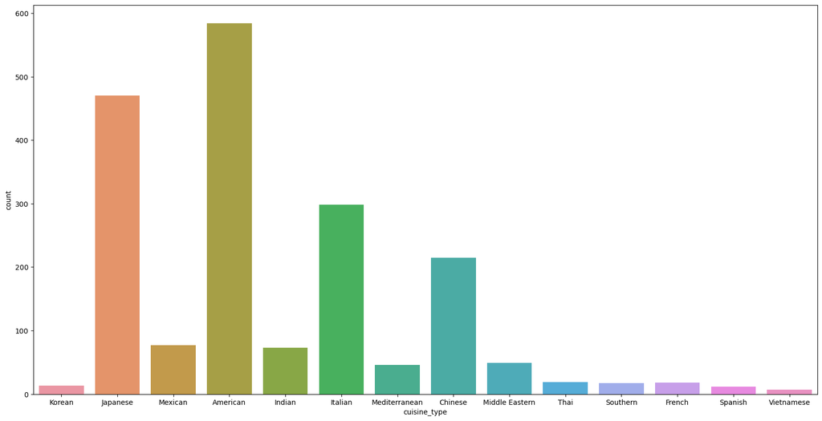

```python
# lets check which cusine type is popular among the orders
plt.figure(figsize = (20, 10))
sns.countplot(x=df['cuisine_type'])
```

```python
df['cuisine_type'].nunique()
```

```
14
```

#### observation

#### Cuisine Popularity:

The plot shows that some cuisines are more popular than others. For instance, the bar representing American cuisine is notably high, suggesting that American food is quite popular among the orders. This is followed by other cuisines like Italian and Japanese, which also seem to be popular, as indicated by the height of their respective bars.

#### Middle-range Cuisines:

Cuisines such as Indian, Mediterranean, and Chinese have a moderate count, indicating a fair level of popularity that is neither as high as American and Italian nor as low as Vietnamese and Spanish.

#### Data Distribution:

The distribution appears to be unimodal but not symmetric, with a skew towards cuisines that are more widely accepted or perhaps more readily available in the dataset's context.

#### cost_of_the_order column

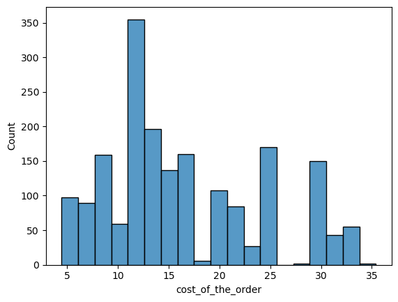

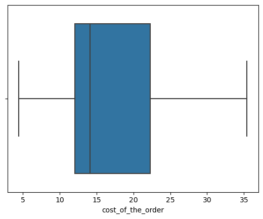

```python
# lets check the cost of the order
sns.histplot(data=df,x='cost_of_the_order')
plt.show()
sns.boxplot(data=df,x='cost_of_the_order')
plt.show()
```

#### Observation

#### Histogram:

The histogram suggests that the distribution of the cost of orders is somewhat right-skewed, with a concentration of orders in the lower price range and fewer orders as the cost increases. The highest frequency of orders falls in the bin that includes the mode of the data, which appears to be between approximately $10 and $15. There are significantly fewer orders above $25, indicating these higher costs are less common.

#### Boxplot:

The median, which is the middle value of the dataset, appears to be around $15 indicated by the line within the box. The "whiskers" of the boxplot (the lines extending from the box) suggest that there are order costs that fall significantly below and above the IQR, but these are within a reasonable range and not classified as outliers in this case. There don't appear to be any outliers on the high or low end, which would be indicated by points beyond the whiskers. This suggests that most of the order costs fall within a somewhat expected range without extreme deviations.

#### day_of_the_week column

```python
# lets check day of the week, with unique values , and countplot for the column

df['day_of_the_week'].nunique()
```

```
2
```

#### Observation

There are only 2 unique values in day of the week, lets check how its divided.

```python
df['day_of_the_week'].value_counts()
```

```
Weekend    1351
Weekday     547
Name: day_of_the_week, dtype: int64
```

#### Observation

we can see that orders are divided between weekend and weekday.

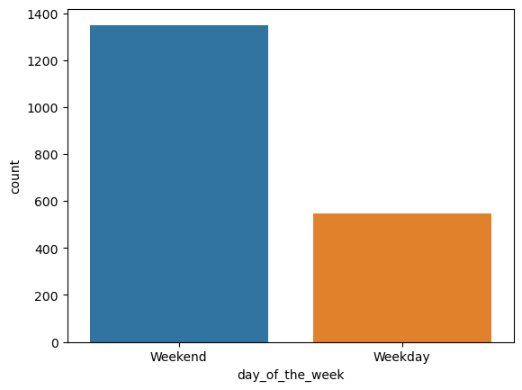

```python
sns.countplot(x=df['day_of_the_week'])
plt.xlabel("day_of_the_week")
plt.ylabel("count")
plt.show()
```

#### Observation

The bar corresponding to the weekend is significantly taller than the bar for the weekday, suggesting that a higher number of orders are placed during the weekend compared to weekdays. The weekend bar reaching well above the 1,000 mark on the count axis, while the weekday bar is shorter, indicating fewer orders.

This suggests that the business might see more activity during the weekends, which could be due to various factors such as customer behavior patterns, leisure time available for ordering food, or special weekend promotions.

#### Rating column

```python
#Lets check the unique values present in rating column
```

```python
df["rating"].nunique()
```

```
4
```

```python
# lets check further how its divided
df["rating"].value_counts()
```

```
Not given    736
5            588
4            386
3            188
Name: rating, dtype: int64
```

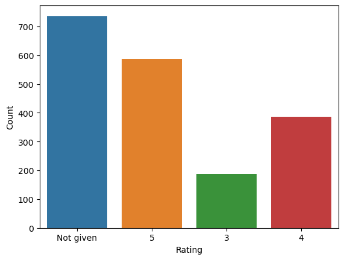

```python
sns.countplot(x=df['rating'])
plt.xlabel('Rating')
plt.ylabel('Count')
plt.show()
```

#### Observations:

The most frequent rating category is 'Not given', with 736 instances, indicating a significant number of orders did not receive a rating. The next most common rating is '5', with 588 instances, suggesting that when customers do provide a rating, they often give the highest score. The count decreases as the rating number decreases, with '4' ratings totaling 386 instances and '3' ratings being the least common among given ratings, with 188 instances. There are no visible bars for ratings '1' and '2', implying that these ratings may have no occurrences or not included in the dataset

# food prepration time

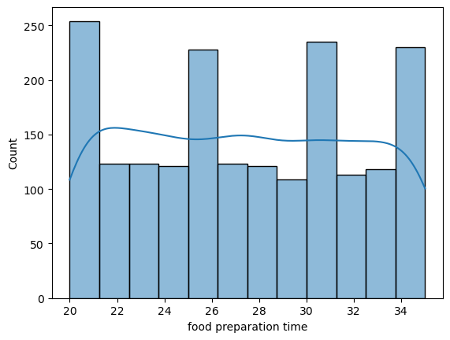

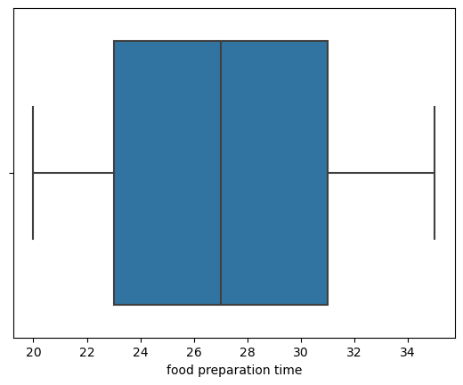

```python
sns.histplot(data=df,x='food_preparation_time',kde=True)
plt.xlabel("food preparation time")
plt.show()
sns.boxplot(data=df,x='food_preparation_time')
plt.xlabel("food preparation time")
plt.show()
```

#### Boxplot:

The boxplot does not show any outliers, which suggests that all food preparation times fall within a relatively expected range. The median food preparation time is indicated by the line within the box and appears to be around 27-28 minutes. The interquartile range (span of the box) is fairly narrow, indicating that 50% of the food preparation times are within a close range of each other. The 'whiskers' of the boxplot, which indicate the range of the data excluding outliers, do not extend much beyond the box, suggesting that most food preparation times are within a moderate range.

# Delivery Time

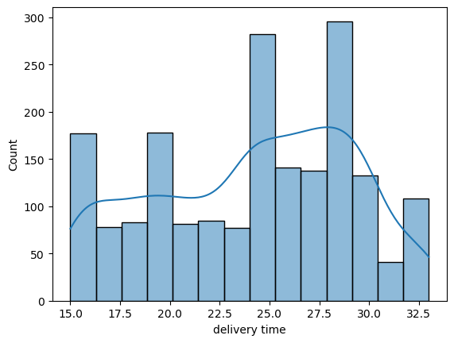

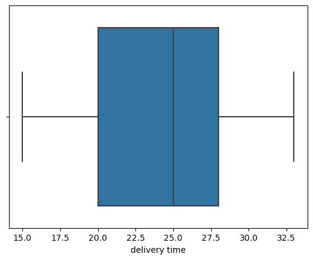

```python
sns.histplot(data=df,x='delivery_time',kde=True)
plt.xlabel("delivery time")
plt.show()
sns.boxplot(data=df,x='delivery_time')
plt.xlabel("delivery time")
plt.show()
```

### **Question 7**: Which are the top 5 restaurants in terms of the number of orders received?

```python
top_5_restaurants = df['restaurant_name'].value_counts().head(5)
top_5_restaurants
```

```
Shake Shack                  219
The Meatball Shop            132
Blue Ribbon Sushi            119
Blue Ribbon Fried Chicken     96
Parm                          68
Name: restaurant_name, dtype: int64
```

#### Observations:

#### Shake Shack: with 219 orders, is the most popular restaurant in the dataset.

#### The Meatball Shop: comes in second with 132 orders.

#### Blue Ribbon Sushi: is the third most frequented with 119 orders.

#### Blue Ribbon Fried Chicken: follows closely behind in fourth place with 96 orders.

#### Parm: rounds out the top five with 68 orders.

Shake Shack leads by a substantial margin, indicating a high level of popularity or brand recognition. This may be attributed to its reputation, quality of food, service, or a combination of these factors.

Cuisine Diversity: The presence of different types of restaurants, such as a burger place, a meatball specialty shop, and sushi restaurants, suggests a diversity in customer preferences and a demand for various cuisines.

Volume Gap: There is a noticeable gap in the number of orders between the top-ranking Shake Shack and the other restaurants. For instance, Shake Shack has 219 orders, which is significantly higher than The Meatball Shop with 132 orders and Blue Ribbon Sushi with 119 orders. This gap could point to market dominance in certain food categories or more effective marketing strategies.

The frequency of orders from these restaurants could also be an indicator of customer loyalty and satisfaction. Regular patronage may result from consistent food quality, customer service, or value for money.

### **Question 8**: Which is the most popular cuisine on weekends?

```python
# Write the code here
popular_cuisine_weekend= df[df['day_of_the_week'] == 'Weekend']['cuisine_type'].value_counts()
popular_cuisine_weekend
```

```
American          415
Japanese          335
Italian           207
Chinese           163
Mexican            53
Indian             49
Mediterranean      32
Middle Eastern     32
Thai               15
French             13
Korean             11
Southern           11
Spanish            11
Vietnamese          4
Name: cuisine_type, dtype: int64
```

#### Observations:

popular cuisine type on the weekend is 'american' with 415 orders.

### **Question 9**: What percentage of the orders cost more than 20 dollars?

```python
percentage = (df[df['cost_of_the_order']>20].shape[0] / df.shape[0]) * 100

print("Percentage of orders above 20 dollars:", round(percentage, 2), '%')
```

```
Percentage of orders above 20 dollars: 29.24 %
```

#### Observations:

Percentage of orders above 20 dollars: 29.24 %

### **Question 10**: What is the mean order delivery time?

```python
df['delivery_time'].mean()
```

```
24.161749209694417
```

### **Question 11:** The company has decided to give 20% discount vouchers to the top 3 most frequent customers. Find the IDs of these customers and the number of orders they placed

```python
most_frequent_customers= df['customer_id'].value_counts().head(3)
most_frequent_customers
```

```
52832    13
47440    10
83287     9
Name: customer_id, dtype: int64
```

#### Observations:

following are the customers with the most orders

#### Customer ID 52832 with 13 orders

#### Customer ID 47440 with 10 orders

#### Customer ID 83287 with 9 orders

### Multivariate Analysis

### **Question 12**: Perform a multivariate analysis to explore relationships between the important variables in the dataset. (It is a good idea to explore relations between numerical variables as well as relations between numerical and categorical variables)

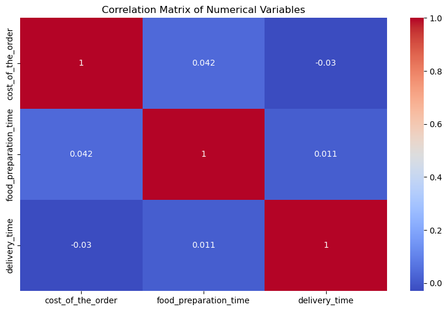

```python
# Write the code here
# Correlation Matrix
plt.figure(figsize=(10, 6))
sns.heatmap(df[['cost_of_the_order', 'food_preparation_time', 'delivery_time']].corr(), annot=True, cmap='coolwarm')
plt.title('Correlation Matrix of Numerical Variables')
plt.show()
```

#### Cost of the Order and Food Preparation Time:

The correlation coefficient is approximately 0.042, indicating a very weak positive relationship between the cost of the order and the time it takes to prepare the food. This suggests that there is no significant relationship, and the cost of the order is not a good predictor of the food preparation time.

#### Cost of the Order and Delivery Time:

The correlation coefficient is approximately -0.03, indicating a negligible negative relationship between the cost of the order and the delivery time. This implies that the cost of the order does not significantly affect the delivery time, and they are essentially unrelated.

#### Food Preparation Time and Delivery Time:

The correlation coefficient is approximately 0.011, which also indicates a very weak positive relationship between the food preparation time and the delivery time. This suggests that there is no significant correlation between how long it takes to prepare the food and how long it takes for the order to be delivered.

#### cost_of_the_order for each cuisine_type

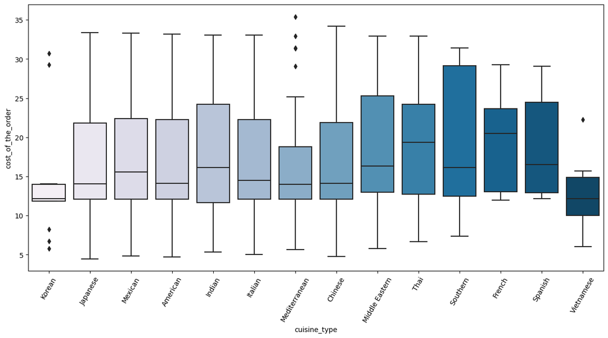

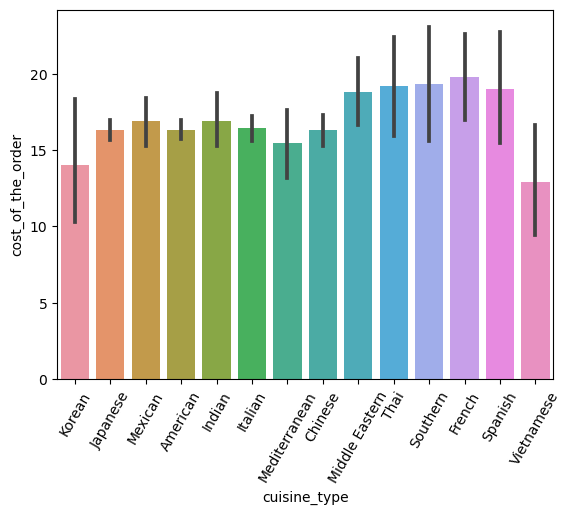

```python
# Relationship between plt.xticks(rotation = 60)
plt.figure(figsize=(15,7))
sns.boxplot(x = "cuisine_type", y = "cost_of_the_order", data = df, palette = 'PuBu')
plt.xticks(rotation = 60)
plt.show()
# Create a barplot to show the average cost_of_the_order for each cuisine_type
sns.barplot(x="cuisine_type", y="cost_of_the_order", data=df)
plt.xticks(rotation = 60)
plt.show()
```

#### cuisine vs food prepration time

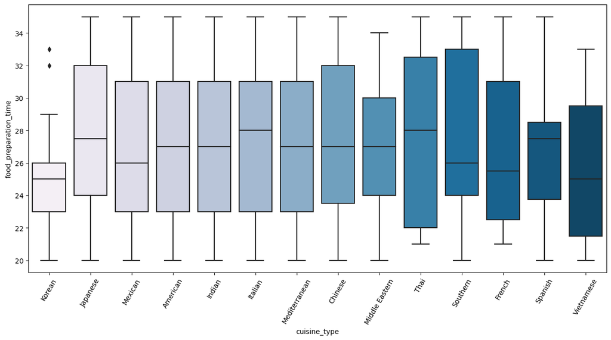

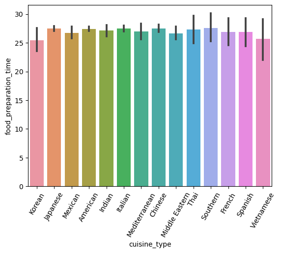

```python
# Relationship between plt.xticks(rotation = 60)
plt.figure(figsize=(15,7))
sns.boxplot(x = "cuisine_type", y = "food_preparation_time", data = df, palette = 'PuBu')
plt.xticks(rotation = 60)
plt.show()
# Create a barplot to show the average cost_of_the_order for each cuisine_type
sns.barplot(x="cuisine_type", y="food_preparation_time", data=df)
plt.xticks(rotation = 60)
plt.show()
```

#### Delivery time on weekend vs weekdays

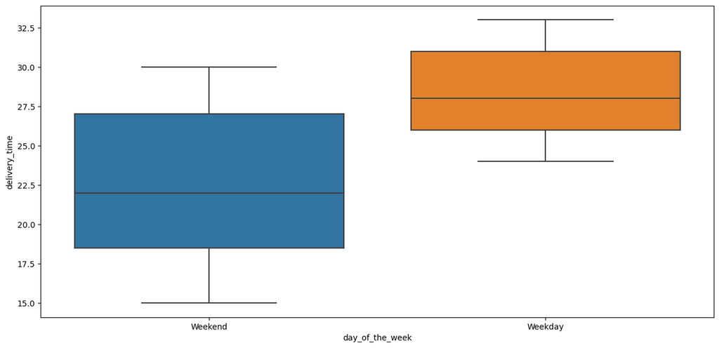

```python
# Relationship between day of the week and delivery time
plt.figure(figsize=(15,7))
sns.boxplot(x='day_of_the_week',y='delivery_time',data=df)  ## Complete the code to visualize the relationship between day of the week and delivery time using boxplot
plt.show()
```

#### Rating vs Delivery time

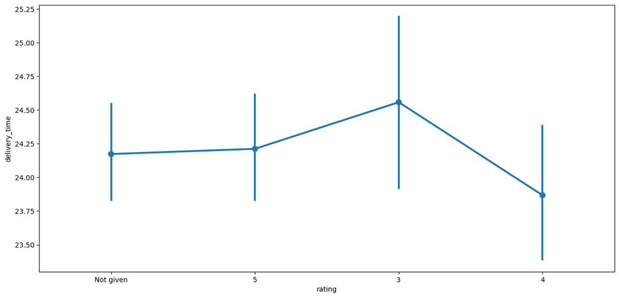

```python
# Relationship between day of the rating and delivery time
plt.figure(figsize=(15,7))
sns.pointplot(x='rating',y='delivery_time',data=df)
plt.show()
```

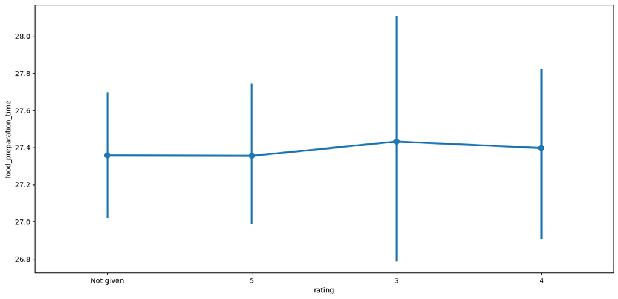

```python
# Relationship between day of the rating and food prepration time
plt.figure(figsize=(15,7))
sns.pointplot(x='rating',y='food_preparation_time',data=df)
plt.show()
```

### **Question 13:** The company wants to provide a promotional offer in the advertisement of the restaurants. The condition to get the offer is that the restaurants must have a rating count of more than 50 and the average rating should be greater than 4. Find the restaurants fulfilling the criteria to get the promotional offer

```python
# Filter the rated restaurants
df_rated = df[df['rating'] != 'Not given'].copy()

# Convert rating column from object to integer
df_rated['rating'] = df_rated['rating'].astype('int')

# Create a dataframe that contains the restaurant names with their rating counts
df_rating_count = df_rated.groupby(['restaurant_name'])['rating'].count().sort_values(ascending = False).reset_index()
df_rating_count.head()
```

|  | restaurant_name | rating |
| --- | --- | --- |
| 0 | Shake Shack | 133 |
| 1 | The Meatball Shop | 84 |
| 2 | Blue Ribbon Sushi | 73 |
| 3 | Blue Ribbon Fried Chicken | 64 |
| 4 | RedFarm Broadway | 41 |

```python
# Get the restaurant names that have rating count more than 50
rest_names = df_rating_count[df_rating_count['rating']>50]['restaurant_name']

# Filter to get the data of restaurants that have rating count more than 50
df_mean_4 = df_rated[df_rated['restaurant_name'].isin(rest_names)].copy()

# Group the restaurant names with their ratings and find the mean rating of each restaurant
df_mean_4.groupby(['restaurant_name'])['rating'].mean().sort_values(ascending = False).reset_index().dropna()
```

|  | restaurant_name | rating |
| --- | --- | --- |
| 0 | The Meatball Shop | 4.511905 |
| 1 | Blue Ribbon Fried Chicken | 4.328125 |
| 2 | Shake Shack | 4.278195 |
| 3 | Blue Ribbon Sushi | 4.219178 |

#### Observations:

Based on the final output displayed, all four listed restaurants would be eligible for the promotional offer, as they all have a rating count of more than 50 (not shown in the output but implied by the filtering step) and an average rating above 4:

The Meatball Shop with an average rating of approximately 4.51. Blue Ribbon Fried Chicken with an average rating of approximately 4.33. Shake Shack with an average rating of approximately 4.28. Blue Ribbon Sushi with an average rating of approximately 4.22.

### **Question 14:** The company charges the restaurant 25% on the orders having cost greater than 20 dollars and 15% on the orders having cost greater than 5 dollars. Find the net revenue generated by the company across all orders

```python
# Write the code here
def calculate_revenue(order_cost):
    if order_cost > 20:
        return 0.25 * order_cost
    elif order_cost > 5:
        return 0.15 * order_cost
    else:
        return 0
df['revenue']=df['cost_of_the_order'].apply(calculate_revenue)
```

```python
total_revenue=df['revenue'].sum()
```

```python
total_revenue
```

```
6166.303
```

#### Observations:

The total revenue generated by the company across all orders is calculated by summing up the revenue column of the DataFrame df.

The final calculated total revenue is $6,166.30.

### **Question 15:** The company wants to analyze the total time required to deliver the food. What percentage of orders take more than 60 minutes to get delivered from the time the order is placed? (The food has to be prepared and then delivered)

```python
# Write the code here
# Calculate total delivery time and add a new column to the dataframe df to store the total delivery time
df['total_time'] = df['food_preparation_time'] + df['delivery_time']
```

```python
# Find the number of orders that took more than 60 minutes to be delivered
orders_over_60_minutes = df[df['total_time'] > 60]

# Calculate the percentage of orders that took more than 60 minutes
percentage_over_60_minutes = (len(orders_over_60_minutes) / len(df)) * 100

percentage_over_60_minutes
```

```
10.537407797681771
```

#### Observations:

majority of the orders (approximately 89.46%) are delivered in 60 minutes or less, which may be considered efficient depending on the company's goals and industry standards. However, the 10.54% of orders that take longer than 60 minutes might be an area to investigate further.

### **Question 16:** The company wants to analyze the delivery time of the orders on weekdays and weekends. How does the mean delivery time vary during weekdays and weekends?

```python
# Get the mean delivery time on weekdays and print it
print('The mean delivery time on weekdays is around',
      round(df[df['day_of_the_week'] == 'Weekday']['delivery_time'].mean()),
     'minutes')

# Get the mean delivery time on weekend and print it
print('The mean delivery time on weekend is around',
      round(df[df['day_of_the_week'] == 'Weekend']['delivery_time'].mean()),
     'minutes')
```

```
The mean delivery time on weekdays is around 28 minutes
The mean delivery time on weekend is around 22 minutes
```

#### Observations:

From these observations, we can deduce that, on average, orders are delivered faster on weekends than on weekdays. This could be due to a variety of factors, such as:

There might be less traffic on the roads during weekends, which can lead to faster delivery times. The volume of orders might be different during weekends compared to weekdays, potentially affecting preparation and delivery processes. The staffing levels or the operational workflows might vary between weekdays and weekends, which can influence how quickly orders are processed and delivered.

### Conclusion and Recommendations

### **Question 17:** What are your conclusions from the analysis? What recommendations would you like to share to help improve the business? (You can use cuisine type and feedback ratings to drive your business recommendations)

### Conclusions:

- The dataset did not have missing values, which indicates good data collection practices.
- Shake Shack emerged as the most popular restaurant in terms of the number of orders.
- American cuisine is the most popular, especially on weekends, suggesting a cultural preference or better availability.
- The cost of orders shows a right-skewed distribution, with most orders being less than $25.
- A significant portion of orders 29.24 percent cost more than $20, which suggests a premium segment of the market.
- The average food preparation time is around 27.37 minutes, with delivery taking just over 24 minutes on average.
- Customer ratings are heavily skewed towards 5, although a substantial number of orders (736) were not rated.
- Four restaurants (The Meatball Shop, Blue Ribbon Fried Chicken, Shake Shack, and Blue Ribbon Sushi) are eligible for a promotional offer due to their high rating counts and average ratings above 4.
- The revenue model of the company earns a substantial amount with a total calculated revenue of $6,166.30, applying a tiered commission structure.
- Approximately 89.46 % of orders are delivered within 60 minutes, indicating efficient operations, but 10.54% exceed this time, which could be a concern.
- Delivery times are, on average, faster on weekends than weekdays, possibly due to different traffic patterns or order volumes.
- Cuisine Popularity Variance: The significant popularity of American cuisine, especially on weekends, hints at consumer preference patterns that can be strategically capitalized on. However, the lower popularity of cuisines like Vietnamese, Spanish, and French suggests untapped market segments or potential gaps in quality or marketing.
- High-Value Orders: The 29.24% of orders costing more than $20 represent a premium customer segment. This group may have different expectations regarding food quality, delivery speed, and service, which can influence their satisfaction and loyalty.
- Efficiency in Delivery: The distinction in delivery times between weekdays and weekends raises questions about operational consistency. Faster delivery on weekends might be influenced by factors like traffic, order volume, and staffing which vary across the week.
- Customer Ratings and Engagement: A large number of orders without ratings (736) points to a potential gap in engaging customers post-delivery. High ratings predominantly skew towards 5, suggesting satisfaction among those who rate, but the absence of feedback from a significant segment might mask underlying issues or areas for improvement.
- Revenue Model Insights: The tiered revenue model based on order value (25% for orders over $20 and 15% for orders over $5) has proven lucrative, with a total revenue of $6,166.30. This model encourages higher-value orders but may need refinement to ensure competitiveness and fairness to restaurant partners.

### Recommendations:

- Customer Engagement: Engage with customers who did not leave a rating to understand their experience and encourage feedback.
- Promotional Strategies: Target promotions towards popular cuisines and restaurants, especially American cuisine and top-performing restaurants like Shake Shack.
- Pricing Strategy: Consider introducing more competitive pricing strategies for orders above 20 dollars to increase the volume of higher-value orders.
- Operational Efficiency: Investigate the reasons behind the 10.54 percent of orders taking longer than 60 minutes and implement measures to reduce this percentage.
- Weekday Delivery Optimization: Since delivery times are slower on weekdays, consider optimizing routes or increasing staffing during peak traffic hours to improve delivery times.
- Data Utilization: Leverage the popularity of high-rating restaurants and cuisines in marketing materials and on the app's homepage to attract new users.
- Loyalty Programs: Introduce loyalty programs for frequent customers to maintain a strong relationship with top customers like those identified for the 20% discount vouchers.
- Menu Diversification: Encourage restaurants offering less popular cuisines to diversify their menu to include items from cuisines that are more popular.
- Delivery Fee Structure: Reassess the tiered commission structure to ensure it aligns with the company's growth strategy and is competitive in the market.
- Customer Service Training: Provide additional training to delivery personnel to enhance customer satisfaction, potentially improving ratings and reducing delivery times.
- Cuisine Diversification and Promotion: Launch targeted campaigns to promote less popular cuisines, possibly through limited-time discounts or featuring specialty dishes to encourage trial among users. Partner with restaurants offering these cuisines to improve their visibility on the app.
- Premium Segment Targeting: Develop premium packages or membership levels offering benefits like reduced delivery fees, priority delivery, or exclusive deals for customers frequently ordering high-value meals. This could enhance loyalty and increase the frequency of high-value orders.
- Operational Analysis and Adjustment: Conduct a detailed analysis of delivery time discrepancies between weekdays and weekends. Consider deploying dynamic routing algorithms and adjusting delivery personnel allocation based on traffic patterns, weather conditions, and historical order volumes.
- Enhanced Customer Feedback Mechanism: Implement more engaging and less intrusive ways to solicit feedback, such as through gamification or offering small incentives for rating orders. Use machine learning to analyze unstructured feedback for insights into customer preferences and pain points.
- Reevaluate Revenue Model: Analyze the impact of the current revenue model on restaurant partners, especially for high-value orders. Consider introducing sliding scales or caps to maintain strong partnerships while ensuring service quality. This could involve a more nuanced approach that takes into account the type of cuisine, order volume, and customer satisfaction scores.
- Broaden Service Offerings: Explore opportunities to diversify the app's offerings, such as introducing meal kits from popular restaurants or scheduling orders in advance for special occasions. This could cater to a broader range of customer needs and occasions, driving growth.